# 수업 과제

Author

홍길동 (2025012345)

Published

March 27, 2026

## Task 1

1. 이전 슬라이드에서 녹색 파스타 비율을 포함하는 `data.frame`을 생성하시오. 이 데이터 프레임의 이름을 `pasta`로 지정하고, 비율을 포함하는 변수를 `prop_green`으로 설정하시오.  
   (힌트: `data.frame()` 함수를 사용하여 데이터 프레임을 생성할 수 있음.)  
   비율 값은 다음과 같음: `(0.7, 0.7, 0.5, 0.5, 0.3, 0.5, 0.4, 0.45, 0.55, 0.4, 0.35, 0.45, 0.45, 0.7, 0.55, 0.5, 0.35, 0.65)`

```r
pasta <- data.frame(prop_green = c(0.7,0.7,0.5,0.5,0.3,0.5,0.4,0.45,0.55,0.4,0.35,0.45,0.45,0.7,0.55,0.5,0.35,0.65))
```

2. `ggplot2`를 사용하여 이 비율의 히스토그램을 생성하시오.  
   `geom_histogram()` 함수에서 다음 매개변수를 사용하시오:  
   `boundary = 0.325, binwidth = 0.05`.

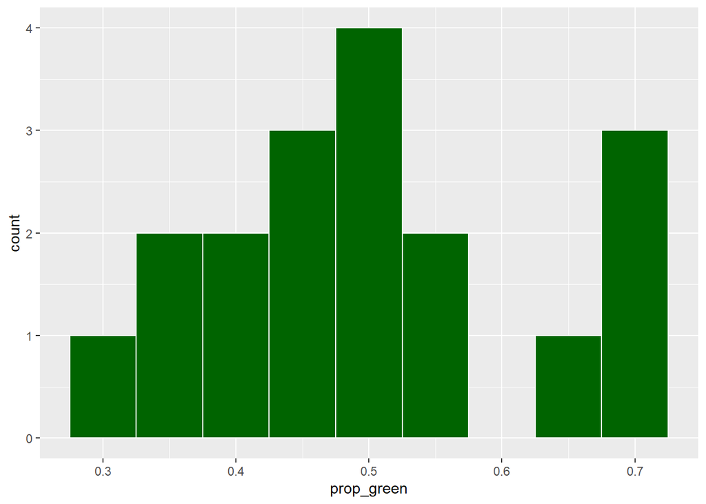

```r
library(tidyverse)
pasta %>%
    ggplot(aes(x = prop_green)) +
    geom_histogram(boundary = 0.325, binwidth = 0.05, color = "white", fill = "darkgreen")
```

3. 무엇을 관찰할 수 있는가?

**약간 정규분포처럼 보이기 시작**

## Task 2

1. 데이터 [링크](https://raw.githack.com/chung-jiwoong/FMB819-Slides/refs/heads/main/chapter_sampling/data/pasta.csv)를 불러와 `pasta` 객체에 저장하라.

```r
pasta <- read.csv("https://raw.githack.com/chung-jiwoong/FMB819-Slides/refs/heads/main/chapter_sampling/data/pasta.csv")
```

2. `moderndive` 패키지의 `rep_sample_n()` 함수를 사용하여 크기 50인 표본을 1000개 생성하라.

```r
library(moderndive)
virtual_samples <- pasta %>%
    rep_sample_n(size = 50, reps = 1000)
```

3. 각 표본에서 초록색 파스타의 비율을 계산하라.

```r
virtual_prop_green <- virtual_samples %>%
    group_by(replicate) %>%
    summarize(
        num_green = sum(color == "green"),
        sample_n = n()) %>%
    mutate(prop_green = num_green / sample_n)
```

4. 각 표본에서 얻은 초록색 파스타 비율의 히스토그램을 그리시오.

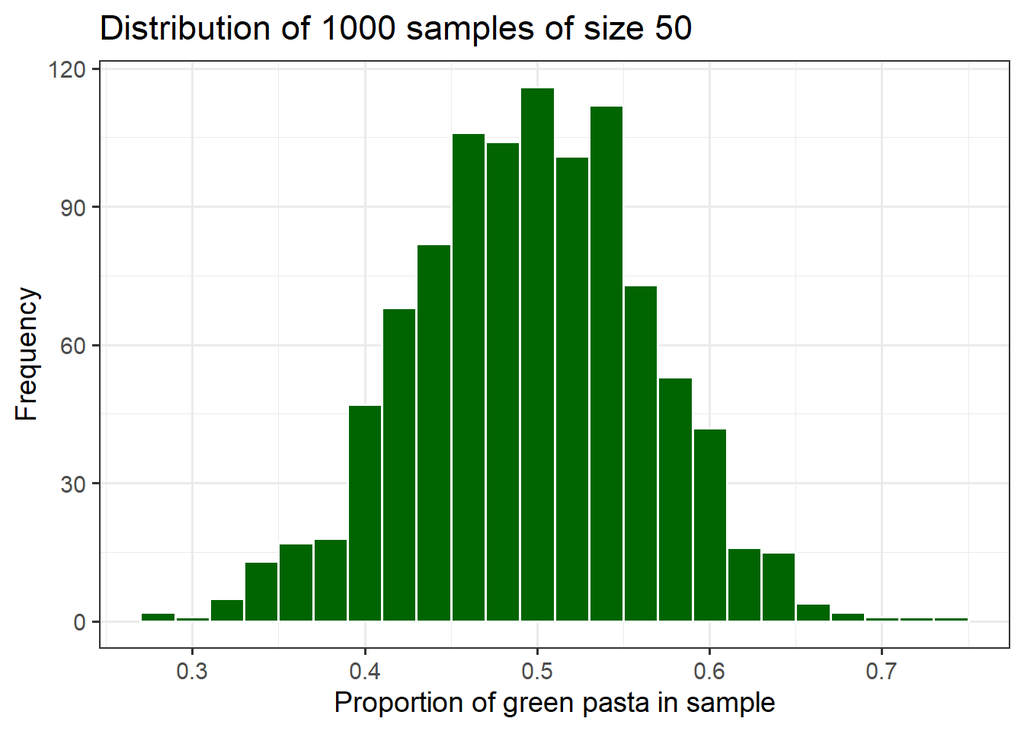

```r
virtual_prop_green %>% ggplot(
    aes(x = prop_green)) +
    geom_histogram(
        binwidth = 0.02,
        boundary = 0.41,
        color = "white",
        fill = "darkgreen") +
    labs(x = "Proportion of green pasta in sample",
         y = "Frequency",
         title = "Distribution of 1000 samples of size 50") +
    theme_bw(base_size = 14)
```

6. 추출한 50개의 파스타 중 초록색 파스타가 20% 미만일 확률은 얼마나 되는가?

**그럴 가능성은 극히 낮습니다.**